# Report

```python
import pandas as pd
import numpy as np
import seaborn as sns
%matplotlib inline
sns.set_style("dark")
from pylab import rcParams
rcParams['figure.figsize'] = 10, 5
import warnings
warnings.filterwarnings("ignore")
from IPython.display import HTML
HTML('''<script>
code_show=true;
function code_toggle() {
 if (code_show){
 $('div.input').hide();
 } else {
 $('div.input').show();
 }
 code_show = !code_show
}
$( document ).ready(code_toggle);
</script>
The raw code for this IPython notebook is by default hidden for easier reading.
To toggle on/off the raw code, click <a href="javascript:code_toggle()">here</a>.''')
```

The raw code for this IPython notebook is by default hidden for easier reading. To toggle on/off the raw code, click here.

```python
df1 = pd.read_csv('auxiliary_classifier_experiment_logs.tsv', sep='\t')
df2 = pd.read_csv('great_experiment_zero_additional.tsv', sep='\t')
df3 = pd.read_csv('great_experiment_zero_additional_again.tsv', sep='\t')
df = pd.concat([df1, df2, df3], keys=['x', 'y', 'z'])
df.dropna(how='all', inplace=True)
dataframes = []
for elem in np.unique(df['number of C0 in D1']):
    dataframes.append(df[df['number of C0 in D1'] == elem])
for dataframe in dataframes:
    dataframe['mean logreg rocauc'] = dataframe['logreg rocauc'].mean()
    dataframe['mean cnn_aux rocauc'] = dataframe['cnn_aux rocauc'].mean()
    dataframe['mean cnn_pure rocauc'] = dataframe['cnn_pure rocauc'].mean()
q = []
for dataframe in dataframes:
    q.append((dataframe['alpha'][0],
              dataframe['beta'][0],
              dataframe['mean logreg rocauc'][0],
              dataframe['mean cnn_aux rocauc'][0],
              dataframe['mean cnn_pure rocauc'][0]))
```

Описание проведённого эксперимента:

Проведена реализация подхода к тренировке классификатора D_0 vs D_1 с помощью вспомогательного классификатора.

Цель - оценить эффективность подходов для различных соотношений размеров классов.

Датасет создал на основе МНИСТа: C_0 - изображения с нулями С_1 - не нули

Соотношения классов такие: C1_in_D0 - 31000 картинок, С1_in_D1 - 31000 картинок, C0_in_D0 - 30 картинок, C1_in_D1 - переменная величина, менялась по ходу эксперимента и была равна [30, 60, 120, 210, 330, 480, 630, 800, 1200, 1700, 2300, 3000] Бил на трейн/тест в соотношении 60%/40%

Для каждой величины C1_in_D1 проведена серия подэкспермиентов, результаты которых усреднялись.

Логистическая регрессия обучалась adam-optimizerom 200 эпох, бралась лучшая из них по скору на тестовой выборке, lr уменьшался при выходе на плато.

После чего на лейблах-предиктах лог.регрессии обучал одну эпоху CNN с архитектурой: input -> conv(3x3, 8 штук, relu) -> conv(3x3, 8 штук, relu) -> maxpool(2) -> conv(3x3, 16 штук, relu) -> conv(3x3, 16 штук, relu) -> dense(в $\mathbb{R}^{128}$, relu) -> dense(в $\mathbb{R}^{128}$, sigmoid) Оптимизатор - adam

После чего обучалась другая копия такой же CNN, но уже на исходных лейблах и две эпохи.

Случай со вспомогательным классификатором работает быстрее на несколько десятков секунд (200 эпох лог.регрессии обучать быстрей, чем 1 эпоху для pure_cnn)

После я выбросил порядка 15% значений - выбросов (rocauc = 0.5, хотя соотношение классов благоприятное для обучения), которые появились неясно из-за чего.

После этого я усреднил рокауки и нарисовал графики зависимости рокаука от величины отношения размеров соответствующих классов:

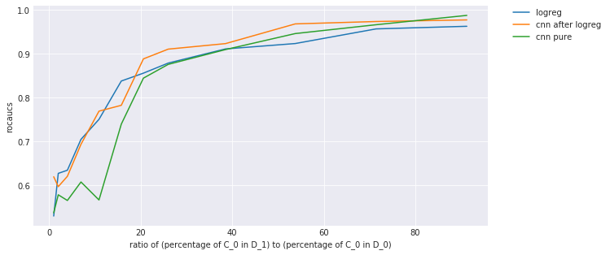

```python
import matplotlib.pyplot as plt
x = [elem[1]/elem[0] for elem in q]
y1 = [elem[2] for elem in q]
y2 = [elem[3] for elem in q]
y3 = [elem[4] for elem in q]
plt.plot(x, y1, label='logreg')
plt.plot(x, y2, label='cnn after logreg')
plt.plot(x, y3, label='cnn pure')
plt.ylabel('rocaucs')
plt.xlabel('ratio of (percentage of C_0 in D_1) to (percentage of C_0 in D_0)')
plt.legend(bbox_to_anchor=(1.05, 1), loc=2, borderaxespad=0.)
plt.grid(True)
plt.show()
```

Можно наблюдать, что подход со вспомогательным классификатором, в целом, работает, и эффективен тем больше, чем ближе x к 1 (но при этом не слишком близко, т.к. тогда классификаторы, по понятным причинам, не особо работают): при малых соотношениях pure_cnn не успевает насмотреться на объекты из С_0 вволю, а лог.регрессия за 200 эпох успевает вполне.

P.S. Отмечу также, что при расширении C_0 другими числами имеет смысл ожидать ухудшения работы подхода, т.к. в этом случае лог.регрессия не сможет так же хорошо "отсечь" кластер-C_0, т.к. объекты из него будут рассредоточены в разных местах $\mathbb{R}^{28*28}$, а поверхность-разделтель почти что линейная.

P.P.S. Отмечу также, что столь многократное обучение классификаторов длится сильно долго, т.к. моя видеокарта не поддерживает новые драйвера от нвидии, необходимые для куды, необходимой для GPU-версии тензорфлоу, а в качестве процессора у меня выступает какая-то вариация на тему core 2 duo. Более того, посреди эксперимента (ставлю обычно на ночь считаться всё) компьютер может внезапно зависнуть и почти ничего не успеть посчитать. Так что было бы здорово, если бы удалось получить какой-то мало-мальски мощный сервер (хорошо бы с gpu) хотя бы на несколько часов в неделю.